# ASE_Beta-Binomial_test

Zhenhua Zhang

February 11, 2019

# ASE Beta-Binomial test

To solve one of the key problem how to model ASE. There are several published methods to model ASE, such as *Binomial dist’n* and *Beta-binomial dist’n*, while the former is **more aggressive** and the later is less.

// Setup of R

```r
rm(list=ls())
library(ggplot2)
```

#### Beta-Binomial probability mass function

A function to calculate the probability of specific amount of successes using logarithm transformation.

```r
bb_pmf <- function(success, trials, alpha=2, beta=3){
  if(success>trials){ return(NULL) }
  numerator <- sum(c(lgamma(trials+1), lgamma(success+alpha),
                     lgamma(trials-success+beta), lgamma(alpha+beta))
                   )
  denominator <- sum(c(lgamma(success+1), lgamma(trials-success+1),
                       lgamma(trials+alpha+beta), lgamma(alpha), lgamma(beta))
                     )
  return(exp(numerator - denominator))  # the exact probability
}
```

#### Beta-Binomial cumulative distribution function

```r
bb_cdf <- function(success, trials, alpha=2, beta=3, init=0){
  if (success < init){ return(NULL) }
  return(sum(sapply(init:success, bb_pmf, trials, alpha, beta)))
}
```

#### Estimation of alpha and beta for Beta-distribution

```r
estimate_alpha_beta <- function(p_vec){
  # The input is a vector of estimated p
  e <- mean(p_vec)
  v <- var(p_vec)
  alpha <- ((1-e)/v - 1/e) * (e^2)
  beta <- alpha*(1/e-1)
  return(c(alpha, beta))
}
```

#### A in progress function to do beta Beta-binomial test

```r
bb_test <- function(successes, trials, target=0.5){
  p_vec <- c(successes / trials)
  ab <- estimate_alpha_beta(p_vec)
  alpha <- ab[[1]]
  beta <- ab[[2]]

  cdf <- bb_cdf(successes, trials, alpha, beta)
}
```

#### A function to fetch minimum successes for specific probability

```r
min_size <- function(p_val, trials, upper, lower=0, alpha=2, beta=3, prec=0.01){
  if(abs(upper-lower) <= 1) {return((upper+lower)/2)}
  area <- bb_cdf((upper+lower)/2, trials, alpha, beta)
  if(abs(area-p_val) <= prec) {
    return((upper+lower)/2)
  } else if(area<p_val) {
    lower <- round((upper+lower)/2)
    min_size(p_val, trials, upper, lower, alpha, beta)
  } else {
    upper <- round((upper+lower)/2)
    min_size(p_val, trials, upper, lower, alpha, beta)
  }
}
```

#### Visualizing *Binomial dist’n*

```r
draw_binom_pmf <- function(trials){
  bars_df <- data.frame(k=0:trials, p=sapply(0:trials, dbinom, trials, 0.5))
  p <- ggplot(data=bars_df, aes(x=k, y=p)) + theme_bw()
  p <- p + geom_line(stat="identity", color='red')
  p
}
```

#### Visualizing Beta-Binomial dist’n

```r
draw_bb_pmf <- function(trials, p_vec=c(), alpha=2, beta=3){
  bars_df <- data.frame(
    k=0:trials, p=sapply(0:trials, bb_pmf, trials, alpha, beta)
    )
  p <- ggplot(data=bars_df, aes(x=k, y=p)) + theme_bw()
  for(p_value in p_vec){
    p <- p + geom_vline(
      xintercept=min_size(p_value, trials, trials, 0, alpha, beta))
  }
  p <- p + geom_line(stat="identity", color='red')
  p
}
```

#### A demo

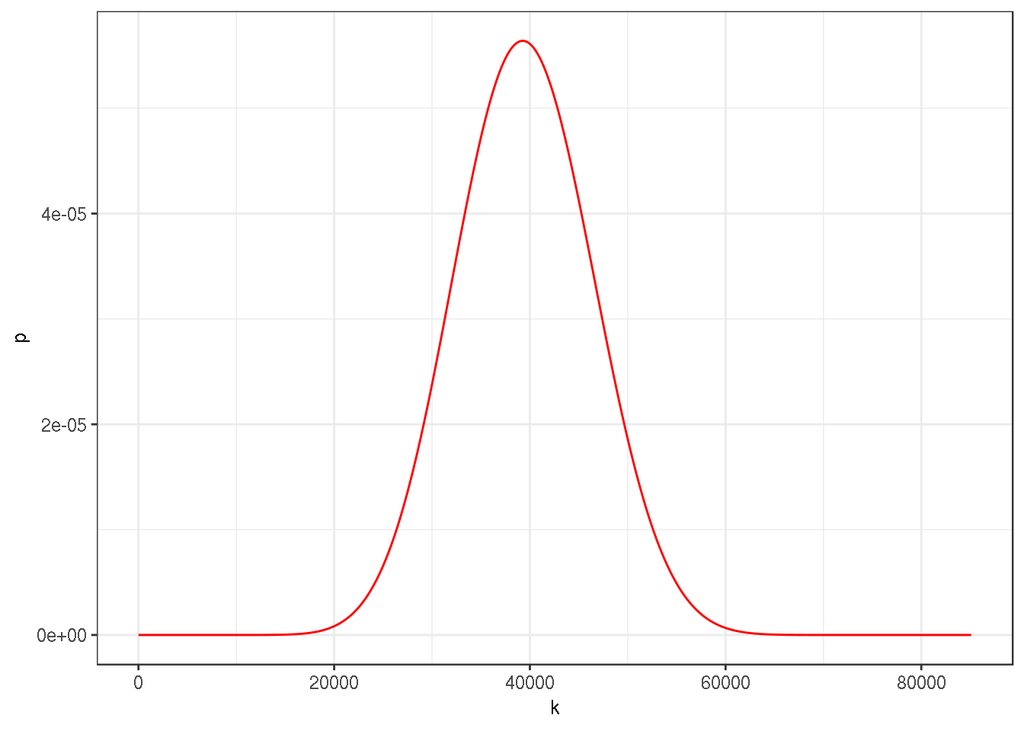

```r
home <- path.expand("~")
input_file <- paste(
  home, "Documents/projects/ASEpredictor/outputs/biosGavinOverlapCov10/NOC2L",
  sep="/"
)
df <- read.csv(input_file, sep="\t")
df$p <- df$altCountsBios / (df$refCountsBios + df$altCountsBios)

ab <- estimate_alpha_beta(df$p)
alpha <- ab[[1]]
beta <- ab[[2]]
succ <- sum(df$altCountsBios)
tria <- sum(df$refCountsBios + df$altCountsBios)
estp <- bb_cdf(tria/2, tria, alpha, beta)
draw_bb_pmf(tria, p_vec=c(), alpha=alpha, beta=beta)
```

```r
dbinom(succ, tria, p=0.5)
```

```
## [1] 2.454555e-110
```

```r
pbinom(succ, tria, p=0.5)
```

```
## [1] 1.732771e-109
```

```r
binom.test(succ+2000, tria, alternative = "less")  # Min. p-value is 2.2e-16.
```

```
##
##  Exact binomial test
##
## data:  succ + 2000 and tria
## number of successes = 41314, number of trials = 85102, p-value <
## 2.2e-16
## alternative hypothesis: true probability of success is less than 0.5
## 95 percent confidence interval:
##  0.0000000 0.4882887
## sample estimates:
## probability of success
##              0.4854645
```

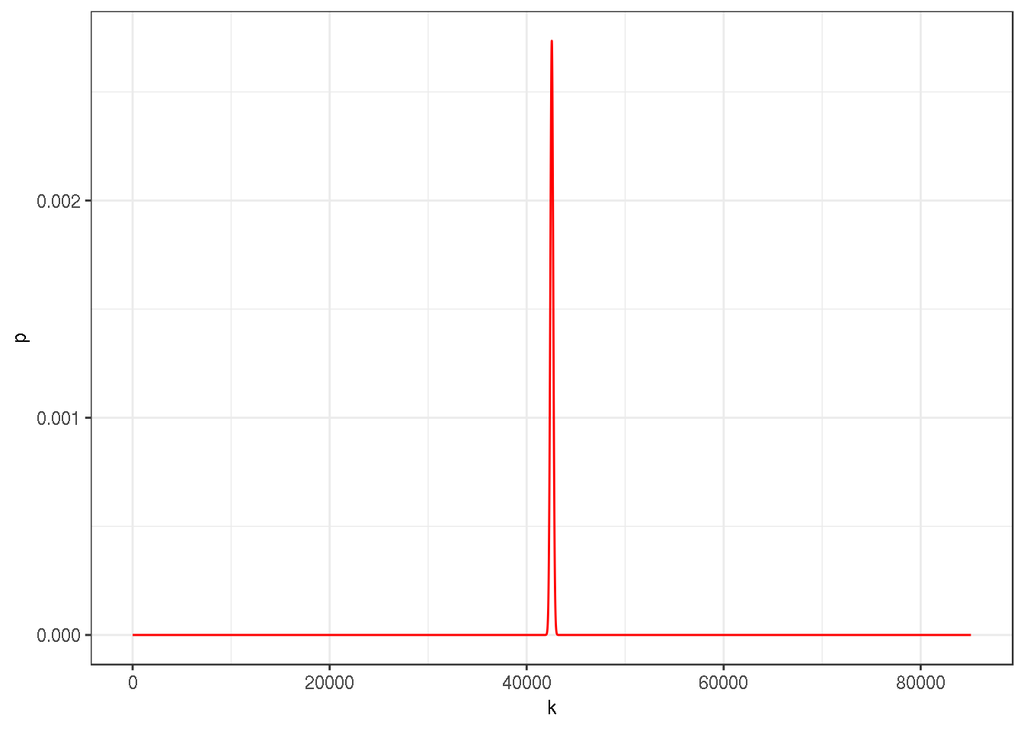

```r
draw_binom_pmf(tria)
```

#### The joint dist’n is indeed a beta-binomial dist’n.

> I think you mean the sum of several binomial random variables

In general, the joint distribution of multiple binomial random variables is still a binomial random variable, when the variables are i.i.d.

Assuming a vector *D* of *i.i.d.* variables from *m* trials:
$$D = (X_1..X_i..X_m), where X_i \sim Binom(n_i, p), where \space i=1..m$$

For each $X_i$, while *p* is identical.
$$\begin{align}
P(X_i=k|p, n_i) & = L(p|k) \\
& = \binom{n}{k}p^k(1-p)^{n_i-k} \\
\end{align}$$
where *k* denotes successes.

Then the joint dist’n is:
$$P(X=\sum{k_i}|p, \sum{n_i}) \sim Binom(\sum{n_i}, p)$$

While if the *p* is various, which is the exact case for ASE, then assuming *p* is respect to *Beta dist’n*. The joint distribution is *Beta-Binomial dist’n*, where *n* is the sum of all trials and *k* are the sum of all successful trials.

Assuming *p* is respect to a *Beta dist’n* with shape parameters $\alpha, \beta$.
$$P = (p_1..p_i..p_m), where \space p_i \sim Beta(\alpha, \beta)$$

The dist’n is:
$$\begin{align}
\pi(p|\alpha,\beta) & = Beta(\alpha, \beta) \\
& = \frac{p^{(\alpha-1)}(1-p)^{(\beta-1)}}{B(\alpha, \beta)}
\end{align}$$

The dist’n of *X* is Beta-Binomial
$$X(k|\sum{n_i}, \alpha, \beta) \sim BetaBinom(\sum{n_i}, \alpha, \beta)$$

The PMF of Beta-Binomial dist’n is :
$$\begin{align}
f(k|\sum{n_i}, \alpha, \beta)
&= \binom{n}{k}\frac{B(k+\alpha, \sum{n_i}-k+\beta)}{B(\alpha, \beta)} \\
&= \frac{\Gamma(n+1)}{\Gamma(k+1)\Gamma(n-k+1)}\frac{\Gamma(k+\alpha)\Gamma(n-k+\beta)}{\Gamma(n+\alpha+\beta)}\frac{\Gamma(\alpha+\beta)}{\Gamma(\alpha)\Gamma(\beta)} \\
\end{align}$$

Alpha and beta for the Beta part can be estimated by the vector of p using formula as the follow1.

$$\begin{align}
\alpha &= \left(\frac{1-\mu}{\sigma^2} - \frac{1}{\mu}\right) \mu^2\\
\beta &= \alpha\left(\frac{1}{\mu} - 1\right)
\end{align}$$

> Note: dbinom() is the PMF, while pbinom() is CDF

The joint probability is calculated by formula, take Bernoulli trials as exp.:
$$L(\theta)= P(X=X_1, X=X_2, ..., X=X_n) = f(x_1;\theta)*f(x_2;\theta)*...*f(x_n;\theta) = \prod^n_{i=1}f(x_i, \theta)$$

### Problems

The joint probability density functions **do not** have expected values; random variables do. Given a unconscious statistician law if $Y=g(X)$, then expected value of *Y* can be found from the disctibution of *X* via:
$$E[Y] = \int^\infty_{-\infty}g(x)f_X(x)dx$$

Here in my case, assuming the observed value $Y=g(X_1, X_2, ..., X_{n-1}, X_n)$
$$E[Y] = \idotsint^{\infty}_{-\infty}g(x_1, x_2,..., x_n)f_{x_1,x_2,...,x_n}(x_1, x_2, ..., x_n)dx_1dx_2...dx_n$$

## Methods in literatures

### Testing allelic imbalance

- Testing a single SNP for allelic imbalance uses a $\chi^2$ goodness-of-fit test for even frequencies of both alleles. When more than one heterozygous SNP are present in the same transcript and the phase is known, the counts can be summed across heterozygous SNPs, counting only once reads overlapping multiple SNPs. This phasing information can be obtained directly from the RNA-seq data, provided that at least one read pair overlaps both heterozygous SNPs. Tools for phasing data from short PE reads (novoPhase, available at http://www.gene.cimr.cam.ac.uk/todd). Alternatively, SNPs in high linkage disequilibrium can be phased in silico, provided that this information is available.2
- To study the effect of allelic differences between the sequence reads and the reference genome they were mapped against, we classified all calls in the dataset as matching the reference allele or the non-reference allele. For each individual, in order to include a SNP in our analysis, we required that at least 20 reads mapped to that SNP position in that individual. The two sequenced individuals were analyzed independently such that two separate tests were performed if both individuals had >20 reads overlapping the same SNP. Foe each individual, we compared the observed distribution of the proportion of mapped reads coming form the reference allele to the expected distribution assuming symmetric binomial sampling. Two one-sided binomial tests were applied to each SNP, to test the complementary alternative hypotheses that expression of the reference allele was greater than or less than 0.5.3

### Adjust mapping bias

- In an attempt to correct for the bias toward preferentially mapping the reference allele, we created a copy of the human genome in which all SNP positions were masked. SNP locations were obtained from the February 2009 releases of the 1000 Genomes project(). Since currently available mapping algorithms do not allow for ambiguity codes in the reference sequence, masking was accomplished by changing the nucleotide at each SNP position to a third allele that is not known segregate in humans(e.g. changint A->T in the reference sequence at the position of an A/G SNP).3

### Adjusting multiple test

- False discovery rate(FDR) corrections were applied across both individuals to correct for multiple testing such that we allowed an overall FDR of 1%, 5% and 10%.3

### References:

[1] For more information about the Beta-distribution, visit https://en.wikipedia.org/wiki/Beta-binomial_distribution  
[2] Genome-wide analysis of allelic expression imbalance in human primary cells by high-throughput transcriptome resequencing  
[3] Effect of read-mapping biases on detecting allele-specific expression from RNA-sequencing data